# CRISPRi library data processing pipeline

## Step 2: DESEQ2 analysis for fold change and significance testing

To obtain fold changes between conditions and a significance metric, the R package DESeq2 was used. DESeq2 uses a negative binomial distribution of read counts to make more accurate estimation of fold change and significance per gene. DESeq2 reference:

*Love, M.I., Huber, W., Anders, S. (2014) Moderated estimation of fold change and dispersion for RNA-seq data with DESeq2. Genome Biology, 15:550. https://doi.org/10.1186/s13059-014-0550-8*

#### 1. Read count matrix

The data frame was reshaped for DESeq2 into a ‘counts matrix’ with genes as rows and samples (conditions) as columns.

```r
counts <- select(df_raw, condition, induction, timepoint, replicate, sgRNA, readcount) %>%

  # paste metadata columns together
  unite(condition, condition, induction, timepoint, replicate) %>%

  # spread condition over columns and sgRNAs over rows
  spread(condition, readcount) %>%

  # remove sgRNA column, replace NA with 0
  mutate_at(vars(-1), function(x) coalesce(x, 0)) %>%

  # add row_names from column
  column_to_rownames("sgRNA")

head(counts)
```

#### 2. Meta data

A meta data frame with experimental annotation is created. This is used to carry out the actual DESeq2 analysis by ‘contrasting’ (comparing) selected conditions to each other.

```r
# The meta data frame with experiment annotation
samples <- data.frame(
  all_conditions = colnames(counts),
  # Order must be same as Reads columns!
  row.names = colnames(counts)
  ) %>%

  # split the metadata into single variables
  separate(all_conditions, into = c("condition", "induction", "timepoint", "replicate")) %>%

  # make combinations of condition, induction and time to form super-groups,
  # then test each time point against each other within the group
  unite(group, condition, induction, timepoint, remove = FALSE)

head(samples)
```

#### 3. Perform DESeq2 analysis

It is possible to use complex experimental designs and specify those using a formula interphase. However, the manual recommends to merge combinations of different factors into super-groups and then do pairwise comparison of the groups one is interested in.

**WARNING: This step is computation-intense and can take several hours**

```r
  DES_result <- DESeqDataSetFromMatrix(
    countData = counts,
    colData = samples,
    design = ~ group) %>%
    DESeq


  # Have alook at the combinations that were tested
  resultsNames(DES_result)[1:10]
```

```r
# list of contrasts/combinations
combinations <- samples$group %>% unique %>%
    grep(pattern = "_([1-9]*|30)$", value = TRUE) %>%
  list(testCond = ., refCond = gsub("_([1-9]*|30)$", "_0", .))


# loop through all possible combinations
DES_result_table = lapply(1:length(combinations$testCond),

  function (i) {
    results(DES_result,
      contrast = c("group", combinations$testCond[[i]], combinations$refCond[[i]])) %>%
    as.data.frame %>%
    mutate(
      sgRNA = rownames(.),
      group = combinations$testCond[[i]]
    ) %>% as_tibble %>%
    separate(group, into = c("condition", "induction", "timepoint")) %>%
    mutate(timepoint = as.numeric(timepoint))
  }

) %>% bind_rows
```

Alternatively, it is possible to load a precumputed DESeq2 results table. This avoids re-running the entire DESeq2 analysis only for another part of the pipeline has changed.

```r
# load precomputed DESeq2 result in form of Rdata object
load("../processed_data/CRISPRi_library_DESeq_result_table.Rdata")
```

## Step 4: Merge with DESeq2 results and summarize data

The following steps condense the raw data frame by averaging replicates, merging the data frame with the result from DESeq2 analysis, and adding different statistical metrics.

```r
# change the grouping to condition, timepoint, induction, sgRNA
df <- group_by(df_raw, condition, timepoint, induction, sgRNA) %>%

  # summarise replicates by mean and stdev
  summarise(
    read.fraction.mean = mean(read.fraction, na.rm = TRUE),
    read.fraction.stdev = sd(read.fraction, na.rm = TRUE)) %>%

  # new grouping for condition, induction, sgRNA BUT NOT timepoint
  group_by(condition, induction, sgRNA) %>%

  # determine FC over time by comparing each sgRNA at each condition
  mutate(FC = read.fraction.mean / read.fraction.mean[1])

# test if mean FC == 1 for all 0d time points and != 1 for all others
df %>% group_by(condition, timepoint, induction) %>%
  summarise(meanFC = mean(FC, na.rm = TRUE)) %>% head
```

| condition | timepoint | induction | meanFC |
| --- | --- | --- | --- |
| L100 | 0 | i | 1.0000000 |
| L100 | 0 | u | 1.0000000 |
| L100 | 1 | i | 0.9550138 |
| L100 | 1 | u | 0.9851857 |
| L100 | 2 | i | 1.0013676 |
| L100 | 2 | u | 1.2149930 |

```r
# merge the dataframe with the result from DESeq2
# this is not trivial because sgRNA and condition have different length
# (DESeq contains all possible combinations of sgRNA and condition, df not)
# a 'left_join' will keep the structure of df
df <- left_join(df, DES_result_table) %>% ungroup
```

## Step 5: Annotation of data

The data frame has to be completed with `NA` for sgRNAs missing in some combinations of conditions. Here, `tidyr::complete` was used to fill these gaps. The syntax is to indicate first the variable that is to be completed, and then the variables that represent conditions to be completed. All other variables (like measurements) are filled with `NA`.

Different annotation columns are added to the master data frame, including a short sgRNA identifier (excluding the position on the gene), an sgRNA index (1 or 2), and the customized genome annotation from Uniprot/KEGG.

```r
df <- df %>% complete(sgRNA, nesting(condition, timepoint, induction)) %>%

  # prepare merging by cleaning IDs from results table
  # first remove sgRNA position number from gene IDs
  mutate(sgRNA_short =
  gsub("(\\_| )[0-9]+(\\_MULTI)?$", "", sgRNA)) %>%

  # add sgRNA index number (1 or 2)
  group_by(condition, timepoint, induction) %>%
  mutate(sgRNA_index = duplicated(sgRNA_short) %>% as.numeric %>% {. + 1}) %>%

  # map trivial names to LocusTags using a manually curated list
  left_join(
    read_tsv("../raw_data/gene_protein_table.txt") %>%
      filter(!duplicated(gene)),
    by = c("sgRNA_short" = "gene")) %>%

  # one more join, this time with the annotation db
  # containing uniprot and categorial (KEGG Brite) data
  left_join(read_csv("../raw_data/Synechocystis_PCC6803_genome_annotation_20190614.csv")[c(1,4:6,11,20,22,27:32)],
    by = c("locus" = "GeneID"))
```

Check that number of detected sgRNAs is the same for all conditions after completing.

```r
  df %>% summarise(length(unique(sgRNA))) %>% head
```

| condition | timepoint | induction | length(unique(sgRNA)) |
| --- | --- | --- | --- |
| L100 | 0 | i | 10498 |
| L100 | 0 | u | 10498 |
| L100 | 1 | i | 10498 |
| L100 | 1 | u | 10498 |
| L100 | 2 | i | 10498 |
| L100 | 2 | u | 10498 |

The number of generations for each experiment and time point was calculated based on known cultivation time and average growth rate in the turbidostat. A fitness score was defined as the area under/over the curve for log2 fold change over number of generations. An enrichment will result in a positive score, a depletion in a negative score. The fitness score is normalized to the maximum number of generations for a particular condition, and is therefore independent of the duration of a particular cultivation. The fitness score will be lower for faster depleting genes and higher for slowly depleting genes.

```r
# using left join with table
df <- left_join(df, read_csv("../raw_data/growth_rate_library.csv")) %>%

  # first fill up missing (NA) log2FC values for the initial 0d time point
  group_by(condition, induction, sgRNA) %>%
  mutate(log2FoldChange = ifelse(FC == 1, 0, log2FoldChange)) %>%

  # determine fitness score using DescTools::AUC()
  mutate(fitness_score = AUC(generations, log2FoldChange)/max(generations)) %>%

  # make temporary change of NACL time points 12 and 30 days to 16 and 32,
  # to ease comparisons. That does not effect the fitness score that was calculated
  # with the accurate time points, nor the number of generations
  ungroup %>% mutate(timepoint = plyr::mapvalues(timepoint, c(12, 30), c(16, 32)))
```

```r
  # check how many sgRNAs have valid scores
  df %>% group_by(condition, induction) %>%
    summarise(total = length(fitness_score), NAs = sum(is.na(fitness_score)))
```

| condition | induction | total | NAs |
| --- | --- | --- | --- |
| L100 | i | 62988 | 1368 |
| L100 | u | 62988 | 120 |
| L300 | i | 62988 | 720 |
| L300 | u | 62988 | 108 |
| LAC | i | 31494 | 5079 |
| LAC | u | 31494 | 3096 |
| LD | i | 31494 | 639 |
| LD | u | 31494 | 57 |
| NACL | i | 31494 | 1392 |

## Step 6: Quality control

The log2 FC that DESeq2 determines takes measures of read density or distribution into account that a manually determined log2 FC does not. A good control of how different a manual log2 FC is from the DESeq2 log2 FC is to simply plot one against the other. There are only minor differences.

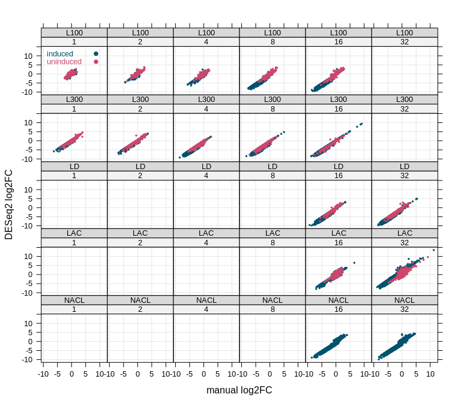

```r
plot_DESeq2_vs_namual_FC <- df %>%

  # plot only genes and remove time point zero
  filter(!grepl("Entry", sgRNA),
    !is.na(log2FoldChange), timepoint != 0) %>%

  xyplot(log2FoldChange ~ log2(FC) | factor(timepoint) *
      factor(condition, c("L100", "L300", "LD", "LAC", "NACL")), .,
    as.table = TRUE, groups = induction,
    par.settings = custom.lattice,
    xlab = "manual log2FC", ylab = "DESeq2 log2FC",
    pch = 19, cex = 0.3,
    scales = list(alternating = FALSE),
    panel = function(x, y, ...) {
      panel.grid(h = -1, v = -1, col = grey(0.9))
      panel.xyplot(x, y, ...)
      panel.key(c("induced", "uninduced"), pch = 19, corner = c(0.1, 0.9))
    }
  )

print(plot_DESeq2_vs_namual_FC)
```

A second check of DESeq2’s calculation of log2 FC and p-value is to visualize both metrics in a volcanoplot. The log2 FC is usually on the x-axis and the negative log10 p-value on the y-axis, showing the most significantly *and* strongly changed genes (here sgRNAs) in the upper right and left corner.

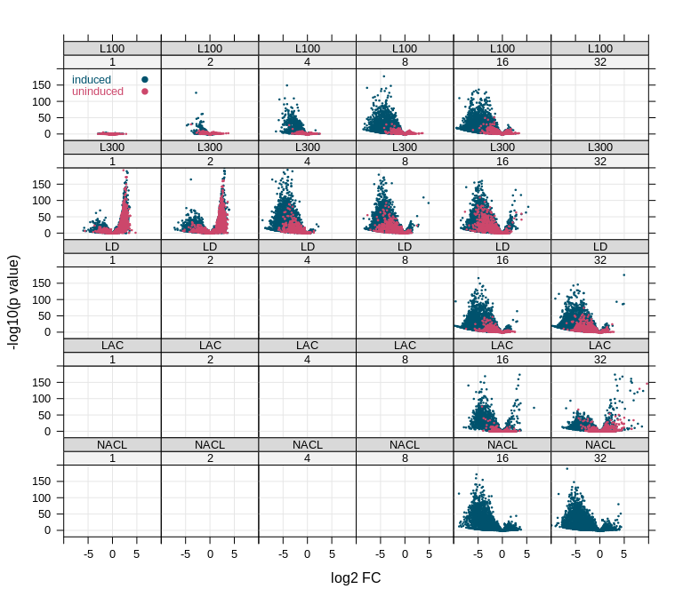

```r
plot_volcanoplot <- df %>%

  # plot only genes and remove time point zero
  filter(!grepl("Entry", sgRNA),
    !is.na(log2FoldChange), timepoint != 0) %>%

  xyplot(-log10(padj) ~ log2FoldChange | factor(timepoint) *
      factor(condition, c("L100", "L300", "LD", "LAC", "NACL")), .,
    as.table = TRUE, groups = induction,
    xlab = "log2 FC", ylab = "-log10(p value)",
    par.settings = custom.lattice,
    cex = 0.2, pch=19,
    scales = list(alternating = FALSE),
    ylim = c(- 20, 200), xlim = c(-10, 10),
    panel = function(x, y, ...) {
      panel.grid(h = -1, v = -1, col = grey(0.9))
      panel.xyplot(x, y, ...)
      panel.key(c("induced", "uninduced"), pch = 19, corner = c(0.1, 0.9))
    }
  )

print(plot_volcanoplot)
```

The last step is to save the DESeq2 result (computatioanlly intense) and the processed data frame to file and continue with the actual analysis of sgRNA enrichment and depletion in the next part of the pipeline.

```r
save(df, file = "../processed_data/CRISPRi_library_df_annotated.Rdata")
save(DES_result_table, file = "../processed_data/CRISPRi_library_DESeq_result_table.Rdata")
```